# Detecting and Correcting for Batch-Effects in scRNAseq Data

Nikolay Oskolkov

September 26, 2017

Abstract

In this lab we will check for presence of batch-effects in the data set and identify genes significantly affected by batch-effects. Further we will show ways removal technical variation due to the batch-effects.

### Load packages

First of all we will R packages which we are going to use in this lab:

```r
library("Seurat")
suppressMessages(require(gplots))
suppressMessages(require(ggplot2))
suppressMessages(require(matrixStats))
suppressMessages(require(mixOmics))
suppressMessages(require(RColorBrewer))
suppressMessages(require(Rtsne))
```

### Load Expression Values and Metadata

Let start with loading the matrix of raw gene expression counts and filtering away genes with median count across all cells below 1, it is very conservative but speeds up computations for this lab. Those genes are lowly expressed genes which should be excluded from the downstream analysis as they might lead to spurious results:

```r
unzip("data/ILC/ensembl_countvalues_ILC.zip", exdir = "data/ILC/")
unzip("data/ILC/ensembl_rpkmvalues_ILC.zip", exdir = "data/ILC/")

D <- read.table("data/ILC/ensembl_countvalues_ILC.csv",sep=",",header=T,row.names=1)

library("matrixStats")
D<-D[rowMedians(as.matrix(D))>=1,]
D[1:5,1:5]
```

```
##                 T74_P1_A9_ILC1 T74_P1_B4_NK T74_P1_B7_ILC2 T74_P1_B9_NK
## ENSG00000002587             25           44             41           40
## ENSG00000003056              0            0              0            1
## ENSG00000003402              2           11              2          657
## ENSG00000003756              0            1             48            3
## ENSG00000004534              1            1           4102            2
##                 T74_P1_D10_ILC2
## ENSG00000002587               5
## ENSG00000003056               1
## ENSG00000003402             924
## ENSG00000003756               1
## ENSG00000004534             672
```

```r
dim(D)
```

```
## [1] 1465  648
```

For the sake of speed and simplicity of this lab we will select only 50% of most varying genes using coefficient of variation as a criterion:

```r
D_var<-apply(D,1,function(x) sd(x)/mean(x))
D<-D[D_var>quantile(D_var,0.5),]
D[1:5,1:5]
```

```
##                 T74_P1_A9_ILC1 T74_P1_B4_NK T74_P1_B7_ILC2 T74_P1_B9_NK
## ENSG00000003056              0            0              0            1
## ENSG00000003402              2           11              2          657
## ENSG00000003756              0            1             48            3
## ENSG00000004534              1            1           4102            2
## ENSG00000004897              0            1              2            2
##                 T74_P1_D10_ILC2
## ENSG00000003056               1
## ENSG00000003402             924
## ENSG00000003756               1
## ENSG00000004534             672
## ENSG00000004897               0
```

```r
dim(D)
```

```
## [1] 732 648
```

The rows of the matrix represent Ensembl gene IDs (you can convert them to gene symbols using biomaRt package) from 732 genes, and the columns are IDs from 648 cells from different individuals sequenced at different plates. To see how many individuals and plates we have let us load the meta-information and have a look:

```r
M <- read.table("data/ILC/Metadata_ILC.csv",sep=",",header=T,row.names=1)
M$Plate<-matrix(unlist(strsplit(as.character(M$Plate),"_")),byrow=TRUE,ncol=2)[,2]
head(M)
```

```
##                 Plate Donor Celltype
## T74_P1_A9_ILC1     P1   T74     ILC1
## T74_P1_B4_NK       P1   T74       NK
## T74_P1_B7_ILC2     P1   T74     ILC2
## T74_P1_B9_NK       P1   T74       NK
## T74_P1_D10_ILC2    P1   T74     ILC2
## T74_P1_E1_ILC3     P1   T74     ILC3
```

```r
summary(M)
```

```
##     Plate              Donor             Celltype
##  Length:648         Length:648         Length:648
##  Class :character   Class :character   Class :character
##  Mode  :character   Mode  :character   Mode  :character
```

Thus we have cells from 3 individuals with IDs:

```r
levels(factor(M$Donor))
```

```
## [1] "T74" "T75" "T86"
```

that were pooled together and sequenced at 4 plates with IDs:

```r
levels(factor(M$Plate))
```

```
## [1] "P1" "P2" "P3" "P4"
```

and finally we have 4 cell-types with the following IDs:

```r
levels(factor(M$Celltype))
```

```
## [1] "ILC1" "ILC2" "ILC3" "NK"
```

The variables Plate and Donor might potentially reflect technical variation due to batch.

### Checking for Genome-Wide Batch-Effects

Now let us check potential batch-effects in the data set. As we saw previously the cells were pooled from 3 and sequenced on 4 plates. Thoese are potential batches. We need to check how they affect gene expression genome-wide. One way to see it is to plot PCA and tSNE and color cells by batch:

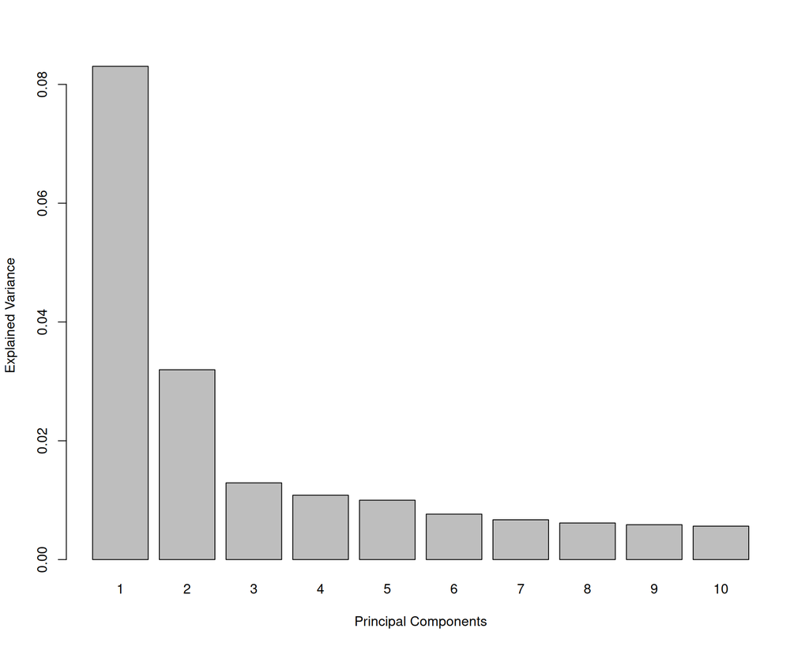

```r
library("mixOmics")
pca.ILC<-pca(log10(t(D+1)),ncomp=10,center=TRUE,scale=FALSE)
plot(pca.ILC)
```

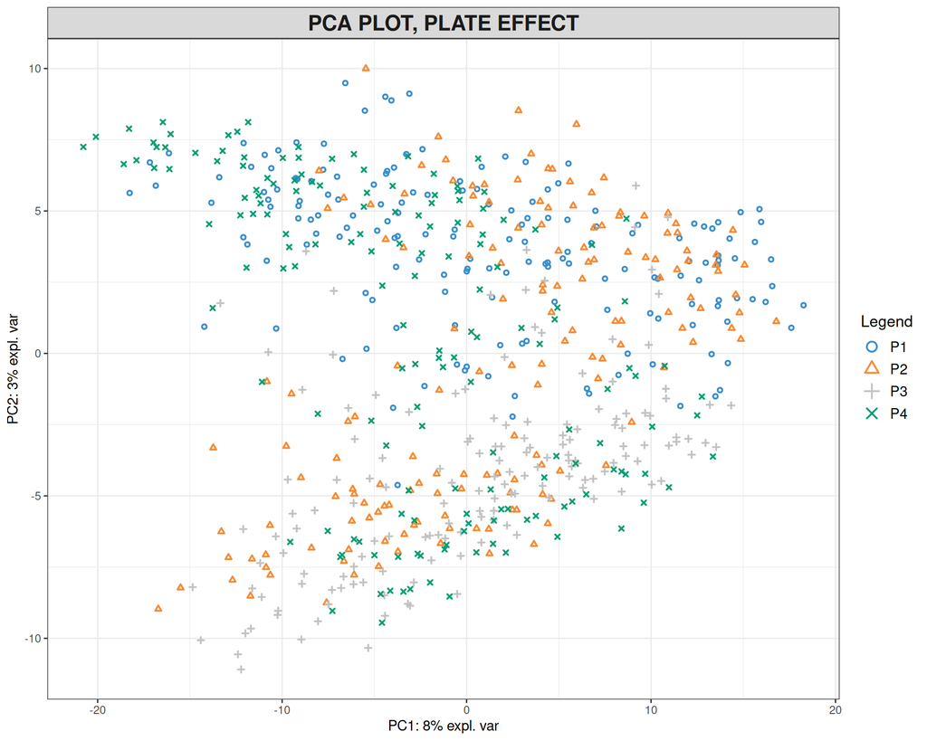

```r
plotIndiv(pca.ILC,group=factor(M$Plate),ind.names=FALSE,ellipse=FALSE,legend=TRUE,title="PCA PLOT, PLATE EFFECT",cex=1)
```

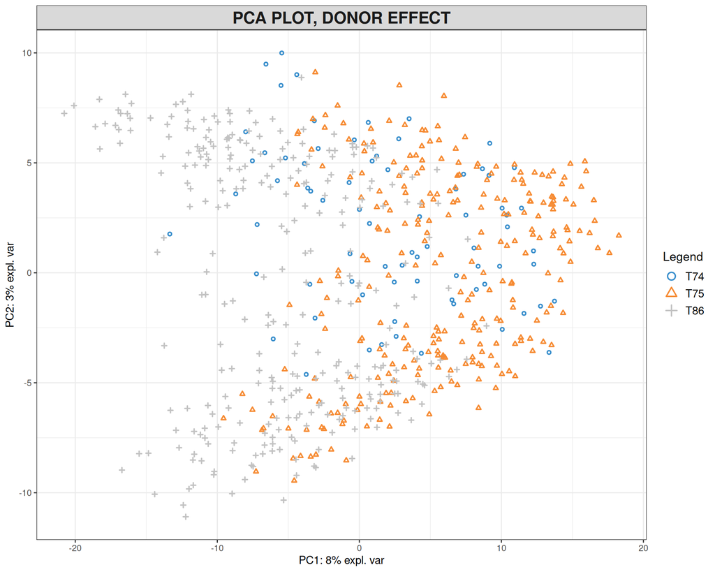

```r
plotIndiv(pca.ILC,group=factor(M$Donor),ind.names=FALSE,ellipse=FALSE,legend=TRUE,title="PCA PLOT, DONOR EFFECT",cex=1)
```

```r
library("Rtsne")
library("RColorBrewer")
set.seed(1)
tsne.out_expr<-Rtsne(t(log10(D+1)),initial_dims=20,verbose=TRUE,perplexity=30)
```

[output not shown]

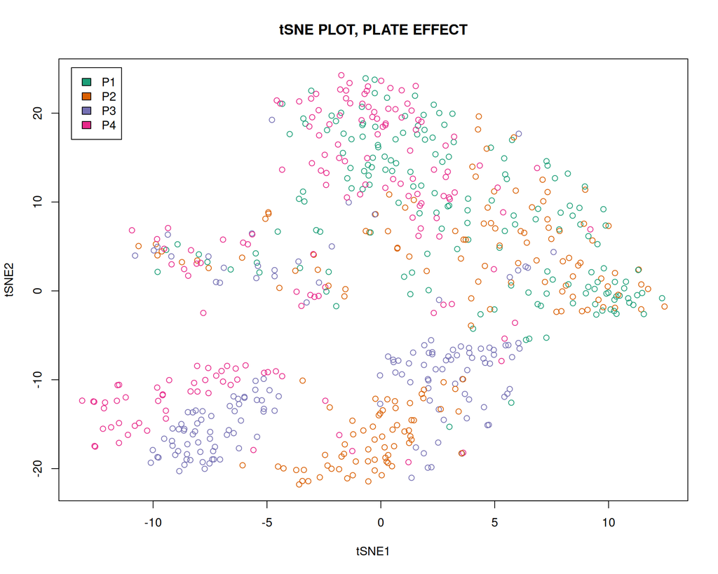

```r
palette(brewer.pal(length(levels(factor(M$Plate))),'Dark2'))
plot(tsne.out_expr$Y,main="tSNE PLOT, PLATE EFFECT",col=factor(M$Plate),xlab="tSNE1",ylab="tSNE2")
legend("topleft",levels(factor(M$Plate)),cex=1,fill=brewer.pal(length(levels(factor(M$Plate))),'Dark2'),inset=0.02)
```

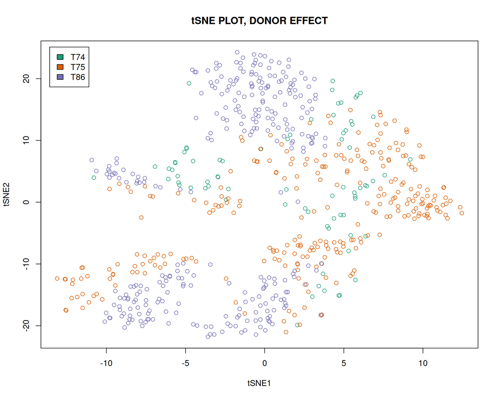

```r
palette(brewer.pal(length(levels(factor(M$Donor))),'Dark2'))
plot(tsne.out_expr$Y,main="tSNE PLOT, DONOR EFFECT",col=factor(M$Donor),xlab="tSNE1",ylab="tSNE2")
legend("topleft",levels(factor(M$Donor)),cex=1,fill=brewer.pal(length(levels(factor(M$Donor))),'Dark2'),inset=0.02)
```

We can immediately see that there is a slight plate related and a more pronounced donor related batch-effect. To further quantify it let us display how much of variation in each principal component is explained by the batch variables:

```r
M$Plate<-factor(M$Plate)
M$Donor<-factor(M$Donor)
M$Celltype<-factor(M$Celltype)

pc_adj_r_squared<-matrix(NA,ncol=dim(pca.ILC$x)[2],nrow=dim(M)[2])
for(i in 1:dim(pca.ILC$x)[2])
{
  print(i)
  for(j in 1:dim(M)[2])
  {
    pc_adj_r_squared[j,i]<-summary(lm(pca.ILC$x[,i]~M[,j]))$adj.r.squared
  }
}
```

```
## [1] 1
## [1] 2
## [1] 3
## [1] 4
## [1] 5
## [1] 6
## [1] 7
## [1] 8
## [1] 9
## [1] 10
```

```r
pc_adj_r_squared<-as.data.frame(pc_adj_r_squared)
colnames(pc_adj_r_squared)<-colnames(pca.ILC$x)
rownames(pc_adj_r_squared)<-colnames(M)
pc_adj_r_squared
```

```
##                 PC1        PC2        PC3        PC4        PC5          PC6
## Plate    0.05180021 0.30492744 0.01855468 0.01573704 0.12226500  0.101180017
## Donor    0.44214488 0.02107709 0.03756549 0.05522430 0.08987487  0.266018738
## Celltype 0.01117032 0.80817822 0.69380232 0.12293283 0.52031296 -0.002524276
##                 PC7          PC8         PC9         PC10
## Plate    0.05824515  0.004760321 0.029266531 0.0333732685
## Donor    0.05135150  0.039968802 0.114280245 0.0081112259
## Celltype 0.02196863 -0.004043204 0.002775554 0.0001119801
```

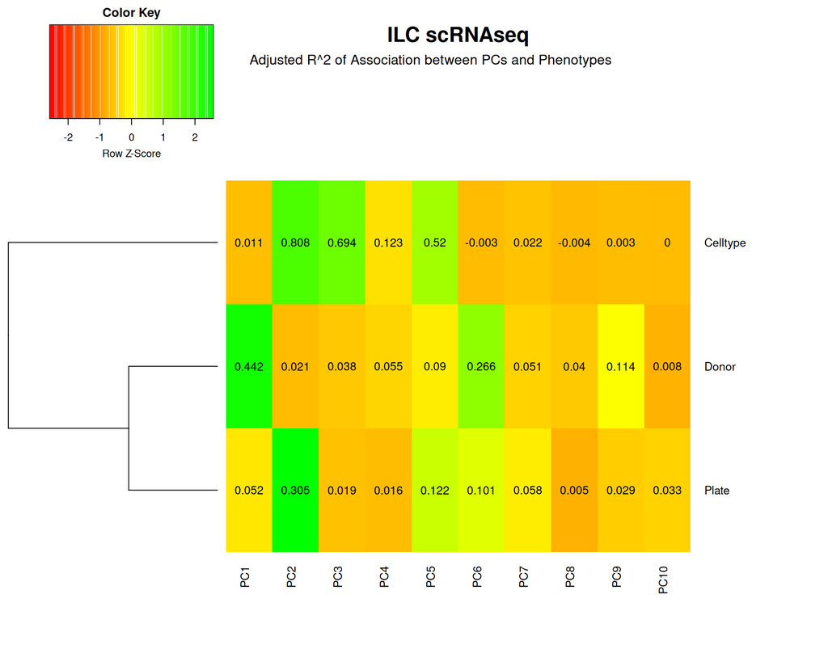

```r
library("gplots")
my_palette <- colorRampPalette(c("red", "yellow", "green"))(n = 299)
heatmap.2(data.matrix(pc_adj_r_squared),cellnote=round(pc_adj_r_squared,3),notecol="black",density.info="none",trace="none",col = my_palette, margins=c(8,10),dendrogram="row",Colv="NA",scale="row",main="ILC scRNAseq",cexRow=1,cexCol=1)
mtext("Adjusted R^2 of Association between PCs and Phenotypes")
```

From the heatmap above it is clear that 44% of PC1 is explained by Donor batch (Celltype contribution is negligible) while 31% of PC2 is explained by Plate batch. In addition, PC2 variation is mainly due to both Celltype and Plate batch, so those two variables are coupled and removing Plate batch could affect the variation due to Celltype which is our phenotype of interest.

### Checking for Per-Gene Batch-Effects

Now let us check batch-effects in the individual genes and figure out genes that are most influenced by batch. Let us check the effect of e.g. Donor on the expression of individual genes. For this purpose we will add a batch variable to the meta information:

```r
M$batch<-M$Donor
head(M)
```

```
##                 Plate Donor Celltype batch
## T74_P1_A9_ILC1     P1   T74     ILC1   T74
## T74_P1_B4_NK       P1   T74       NK   T74
## T74_P1_B7_ILC2     P1   T74     ILC2   T74
## T74_P1_B9_NK       P1   T74       NK   T74
## T74_P1_D10_ILC2    P1   T74     ILC2   T74
## T74_P1_E1_ILC3     P1   T74     ILC3   T74
```

Now we will rank all genes by the percentage of variation in their expression explained by the batch factor variable:

```r
adj_r_squared<-vector()
for(i in 1:dim(D)[1])
{
  adj_r_squared<-append(adj_r_squared,summary(lm(as.numeric(D[i,])~M$batch))$adj.r.squared)
}
adj_r_squared[adj_r_squared<0]<-0
var_expl<-data.frame(genes=rownames(D),var_expl=adj_r_squared)
var_expl<-var_expl[order(-var_expl$var_expl),]
head(var_expl,20)
```

```
##               genes   var_expl
## 686 ENSG00000237973 0.57125722
## 662 ENSG00000225630 0.44484858
## 711 ENSG00000256618 0.34349035
## 665 ENSG00000227097 0.23221658
## 663 ENSG00000225840 0.18835454
## 271 ENSG00000128016 0.15331071
## 723 ENSG00000265150 0.10330701
## 678 ENSG00000233927 0.09043639
## 725 ENSG00000265735 0.07175026
## 706 ENSG00000253676 0.07022771
## 315 ENSG00000135018 0.06775005
## 606 ENSG00000197183 0.06372930
## 17  ENSG00000026025 0.06247762
## 692 ENSG00000243101 0.05875688
## 691 ENSG00000241529 0.05507034
## 198 ENSG00000115085 0.05442117
## 363 ENSG00000142347 0.05411619
## 434 ENSG00000159388 0.05308169
## 641 ENSG00000210184 0.05274778
## 602 ENSG00000197043 0.05198533
```

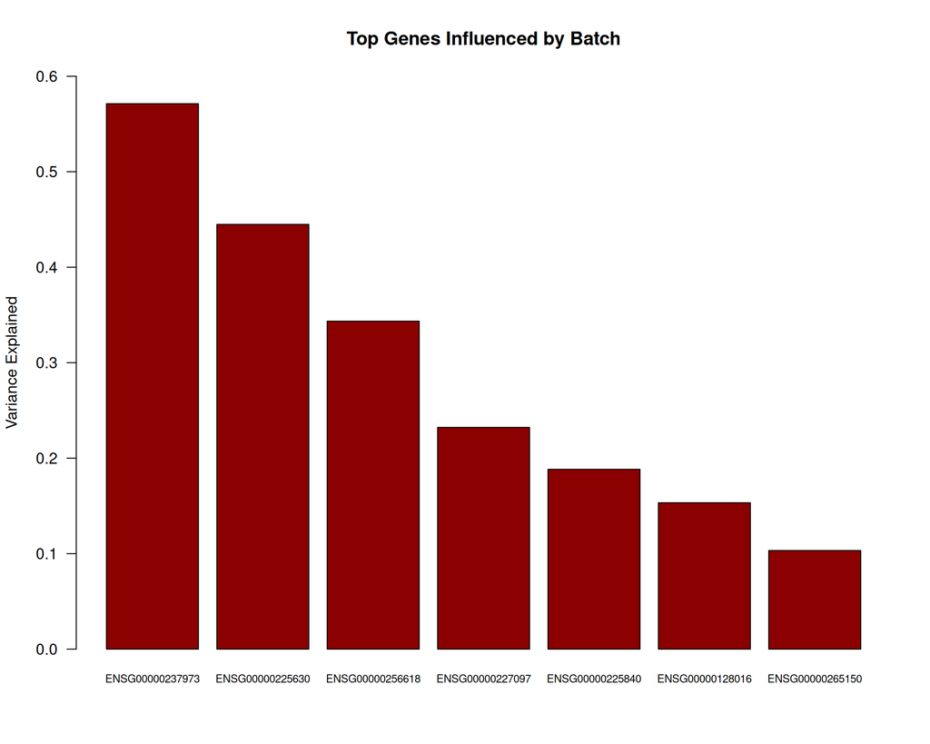

```r
barplot(var_expl$var_expl[1:7],names=var_expl$genes[1:7],ylab="Variance Explained",main="Top Genes Influenced by Batch",col="darkred",las=1,cex.names=0.7,ylim=c(0,0.6))
```

Thus we conclude that the batch-effect might explain up to ~60% of variation in gene expression of most affected genes.

Let us also check which batch is the most influential:

```r
my_batches<-levels(M$batch)
my_genes<-as.character(var_expl$genes)
adj_r_squared_per_species<-list()
for(j in 1:length(my_genes))
{
  adj_r_squared_per_batch<-vector()
  for(i in 1:length(my_batches))
  {
    this_batch<-factor(ifelse(as.character(M$batch)==my_batches[i],my_batches[i],paste0("NOT_",my_batches[i])))
    adj_r_squared_per_batch<-append(adj_r_squared_per_batch,summary(lm(as.numeric(D[my_genes[j],])~this_batch))$adj.r.squared)
    adj_r_squared_per_batch[adj_r_squared_per_batch<0]<-0
  }
  adj_r_squared_per_species[[j]]<-adj_r_squared_per_batch
}
batch_matrix<-matrix(unlist(adj_r_squared_per_species),ncol=length(my_batches),byrow=TRUE)
batch_df<-as.data.frame(batch_matrix)
rownames(batch_df)<-my_genes
colnames(batch_df)<-my_batches
batch_df[1:10,1:3]
```

```
##                          T74        T75          T86
## ENSG00000237973 0.5716699265 0.06034322 5.576458e-02
## ENSG00000225630 0.0411298712 0.44570792 2.790453e-01
## ENSG00000256618 0.3444955019 0.03258765 3.626696e-02
## ENSG00000227097 0.0110460685 0.16974774 2.306282e-01
## ENSG00000225840 0.0009035628 0.15678101 1.797534e-01
## ENSG00000128016 0.0195376825 0.09133304 1.544442e-01
## ENSG00000265150 0.0995958719 0.02603911 1.785723e-05
## ENSG00000233927 0.0002767789 0.08905885 7.171379e-02
## ENSG00000265735 0.0552986786 0.03877870 5.575910e-04
## ENSG00000253676 0.0000000000 0.05945957 6.767231e-02
```

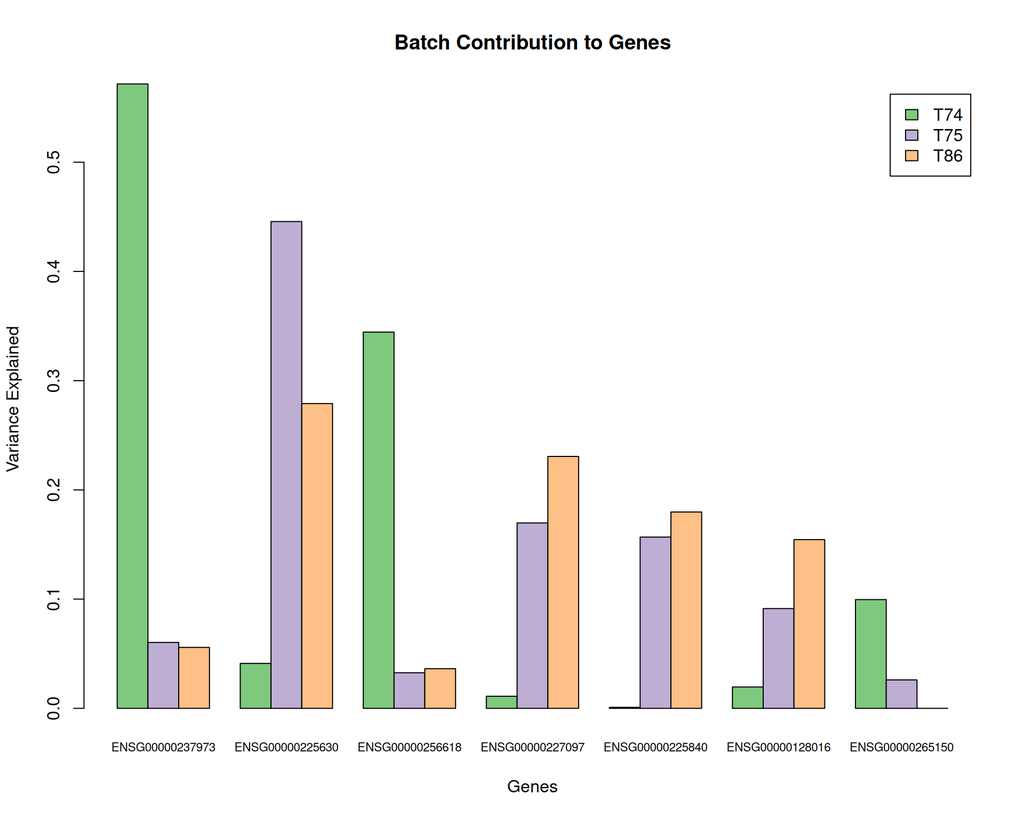

```r
n <- length(my_batches)
library("RColorBrewer")
qual_col_pals = brewer.pal.info[brewer.pal.info$category == 'qual',]
col_vector = unlist(mapply(brewer.pal, qual_col_pals$maxcolors, rownames(qual_col_pals)))
barplot(t(batch_matrix[1:7,]),beside=TRUE,ylab="Variance Explained",names.arg=my_genes[1:7],legend=my_batches,col=col_vector[1:length(my_batches)],cex.names=0.7,xlab="Genes",main="Batch Contribution to Genes")
```

Overall, it seems that different genes are affected by contributions from different individuals.

However, what would be variance explained by chance alone? To elucidate this we will perform a number of shuffling of expression vectors for each gene individually and calculate the shuffled variance explained, i.e. the variance explained by chance for each gene. Further, we will plot the noise zone as three standard deviations beyond the mean of shuffled variance explained.

```r
N_shuffle_ind<-100
ranked_genes<-as.character(var_expl$genes)
shuffle_stat_ind<-list()
for(i in 1:length(ranked_genes))
{
  adj_r_squared_shuffle_ind<-vector()
  for(j in 1:N_shuffle_ind)
  {
    gene_shuffle<-
      as.numeric(D[ranked_genes[i],][sample(1:dim(D)[2],dim(D)[2])])
    adj_r_squared_shuffle_ind<-
      append(adj_r_squared_shuffle_ind,summary(lm(gene_shuffle~M$batch))$adj.r.squared)
  }
  adj_r_squared_shuffle_ind[adj_r_squared_shuffle_ind<0]<-0
  shuffle_stat_ind[[i]]<-adj_r_squared_shuffle_ind
}
shuffle_matrix_ind<-t(matrix(unlist(shuffle_stat_ind),byrow=TRUE,ncol=N_shuffle_ind))
shuffle_matrix_ind[1:5,1:5]
```

```
##              [,1] [,2]         [,3] [,4]         [,5]
## [1,] 0.0000000000    0 0.0000000000    0 0.000000e+00
## [2,] 0.0000000000    0 0.0000000000    0 2.880847e-04
## [3,] 0.0000000000    0 0.0000000000    0 0.000000e+00
## [4,] 0.0004656442    0 0.0007258441    0 5.046332e-05
## [5,] 0.0041697381    0 0.0013451409    0 0.000000e+00
```

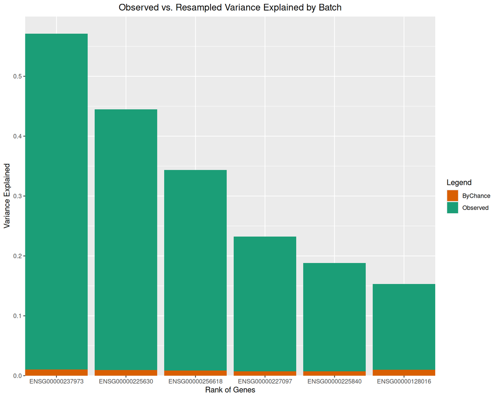

```r
library("matrixStats")
noise<-colMeans(shuffle_matrix_ind)+3*colSds(shuffle_matrix_ind)

library("ggplot2")
library("RColorBrewer")
Observed<-data.frame(ranked_genes=ranked_genes,var_expl=var_expl$var_expl)[1:6,]
ByChance<-data.frame(ranked_genes=ranked_genes,var_expl=noise)[1:6,]
ggplot(NULL, aes(ranked_genes,var_expl)) +
  geom_bar(aes(fill="Observed"),data=Observed,stat='identity') +
  geom_bar(aes(fill="ByChance"),data=ByChance,stat='identity') +
  ggtitle("Observed vs. Resampled Variance Explained by Batch") +
  xlab("Rank of Genes") + ylab("Variance Explained") +
  scale_x_discrete(limits = ranked_genes[1:6], expand = c(0.01,0.01)) +
  scale_y_continuous(expand = c(0.0,0)) + coord_cartesian(ylim=c(0,0.6)) +
  theme(plot.title=element_text(hjust = 0.5)) +
  scale_fill_manual(name="Legend",values=c(brewer.pal(8,'Dark2')[2],brewer.pal(8,'Dark2')[1]))
```

Above we displayed just a few most influenced by batch genes (observed) together with the shuffled variance explained (by chance). Here we can see that e.g. ENSG00000237973 seems to be strongly influenced by batch effects since the observed variance explained is beyond three standard deviations from the mean of variance explained by chance.

Now let us display the variance explained by batch for all genes in the ordered way (from largest to lowest) by a curve (observed) together with shuffled variance explained (by chance). Again, mean + 3 standard deviations from the mean is the noise zone boundary:

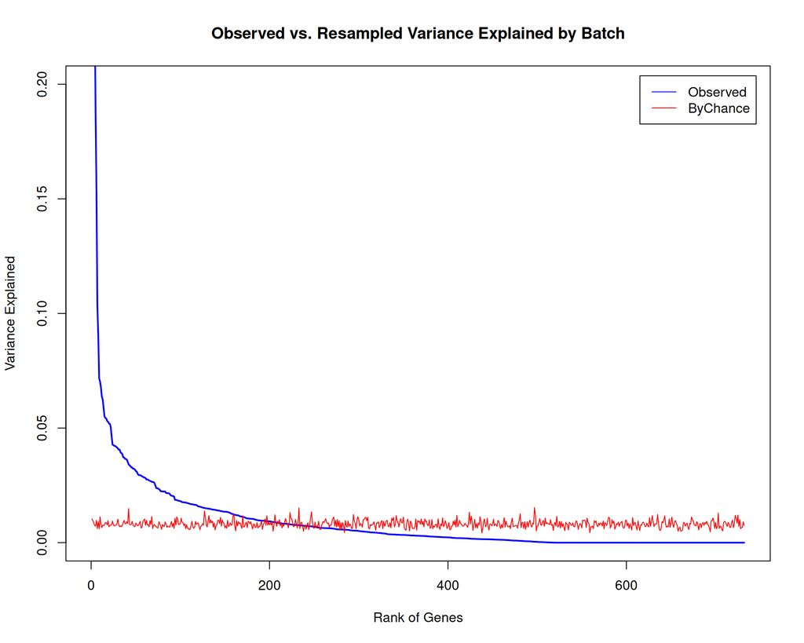

```r
plot(var_expl$var_expl~seq(1:length(var_expl$var_expl)),xlab="Rank of Genes",ylab="Variance Explained",col="blue",main="Observed vs. Resampled Variance Explained by Batch",type="l",lwd=2,ylim=c(0,0.2))
lines(noise~seq(1:length(var_expl$var_expl)),col="red")
legend("topright",inset=0.02,c("Observed","ByChance"),col=c("blue","red"),lty=c(1,1))
```

Here we can see that the observed variance explained hits the noise zone for approximately gene #200 meaning that approximately top 200 genes ordered by their variance explained by batch are significantly influenced by batch, the rest genes are safe to use in the downstream analysis. We can also do a formal statistical test and calculate a p-value of significance of deviation from the noise zone. The p-value represents how many times shuffled variance explained by batch is equal or below the noise zone. We also apply Benjamini-Hochberg correction of th p-values for multiple testing:

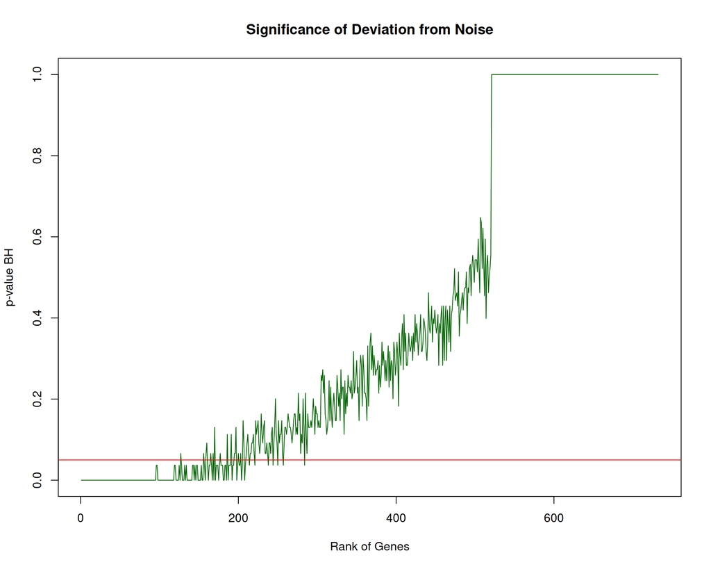

```r
p_res<-vector()
for(i in 1:dim(shuffle_matrix_ind)[2])
{
  p_res<-append(p_res,sum(shuffle_matrix_ind[,i]>=var_expl$var_expl[i])/dim(shuffle_matrix_ind)[1])
}
p_res_BH<-p.adjust(p_res,method="BH")
plot(p_res_BH~seq(1:dim(shuffle_matrix_ind)[2]),type='l',col="darkgreen",xlab="Rank of Genes",ylab="p-value BH",main="Significance of Deviation from Noise")
abline(h=0.05,col="red")
```

Again, we see that the top ca. 200 genes seem to be significantly influenced by the batch-effects. Finally, let us display the genes that are significantly influenced by batch-effects to have a look and memorize them:

```r
problematic_genes<-data.frame(species=ranked_genes,var_expl_by_batch=var_expl$var_expl,pvalue=p_res,FDR=p_res_BH)
problematic_genes<-problematic_genes[order(problematic_genes$FDR,problematic_genes$pvalue,-problematic_genes$var_expl_by_batch),]
bad_genes<-problematic_genes[problematic_genes$FDR<=0.05,]
good_genes<-problematic_genes[problematic_genes$FDR>0.05,]
```

Thus here are “bad genes” ordered by how strongly they are affected by batch-effects, i.e. the higher in the list the more affected:

```r
head(bad_genes,50)
```

```
##            species var_expl_by_batch pvalue FDR
## 1  ENSG00000237973        0.57125722      0   0
## 2  ENSG00000225630        0.44484858      0   0
## 3  ENSG00000256618        0.34349035      0   0
## 4  ENSG00000227097        0.23221658      0   0
## 5  ENSG00000225840        0.18835454      0   0
## 6  ENSG00000128016        0.15331071      0   0
## 7  ENSG00000265150        0.10330701      0   0
## 8  ENSG00000233927        0.09043639      0   0
## 9  ENSG00000265735        0.07175026      0   0
## 10 ENSG00000253676        0.07022771      0   0
## 11 ENSG00000135018        0.06775005      0   0
## 12 ENSG00000197183        0.06372930      0   0
## 13 ENSG00000026025        0.06247762      0   0
## 14 ENSG00000243101        0.05875688      0   0
```

[output cut: 36 more lines]

```r
dim(bad_genes)[1]
```

```
## [1] 199
```

And here come genes that are ok to use for the downstream analysis since they are not significantly affected by batch effects:

```r
head(good_genes,50)
```

```
##             species var_expl_by_batch pvalue        FDR
## 127 ENSG00000119801       0.015191455   0.02 0.06594595
## 156 ENSG00000138767       0.012993687   0.02 0.06594595
## 159 ENSG00000126353       0.012503202   0.02 0.06594595
## 165 ENSG00000109046       0.011922635   0.02 0.06594595
## 168 ENSG00000158869       0.011413924   0.02 0.06594595
## 177 ENSG00000159461       0.010531282   0.02 0.06594595
## 195 ENSG00000136003       0.009505694   0.02 0.06594595
## 196 ENSG00000198408       0.009484688   0.02 0.06594595
## 200 ENSG00000127483       0.009306217   0.02 0.06594595
## 203 ENSG00000119707       0.009094716   0.02 0.06594595
## 210 ENSG00000106028       0.008642442   0.02 0.06594595
## 213 ENSG00000171490       0.008483861   0.02 0.06594595
## 215 ENSG00000103479       0.008295441   0.02 0.06594595
## 216 ENSG00000153922       0.008295003   0.02 0.06594595
```

[output cut: 36 more lines]

```r
dim(good_genes)[1]
```

```
## [1] 533
```

### Correcting for Batch-Effects with Combat

Here we will use Combat in order to remove batch-effects due to different Donors. Combat has an advantage compared to simple linear regression batch-effects removal implemented e.g. in Limma since it uses Bayesian framework and works well even for low numbers of samples/cells. Particular advantage of the Combat batch effect removal is that it uses so-called “Bayesian shrinkage towards the mean”, i.e. correction of each gene uses a “mean” information from other genes which Limma does Frequentist batch-effect correction gene-by-gene independently. We assume that the different Donor and Plate can be viewed as a bacth which can be removed with Combat.

An important step to do before running Combat is to show the phenotype of interst (which is Celltype in our case) to the algorithm. In this way we are saying: do not touch the variation due to the Celltype, correct for the differences in Donor only.

```r
library("sva")
```

```
## Found3batches
```

```
## Adjusting for3covariate(s) or covariate level(s)
```

```
## Standardizing Data across genes
```

```
## Fitting L/S model and finding priors
```

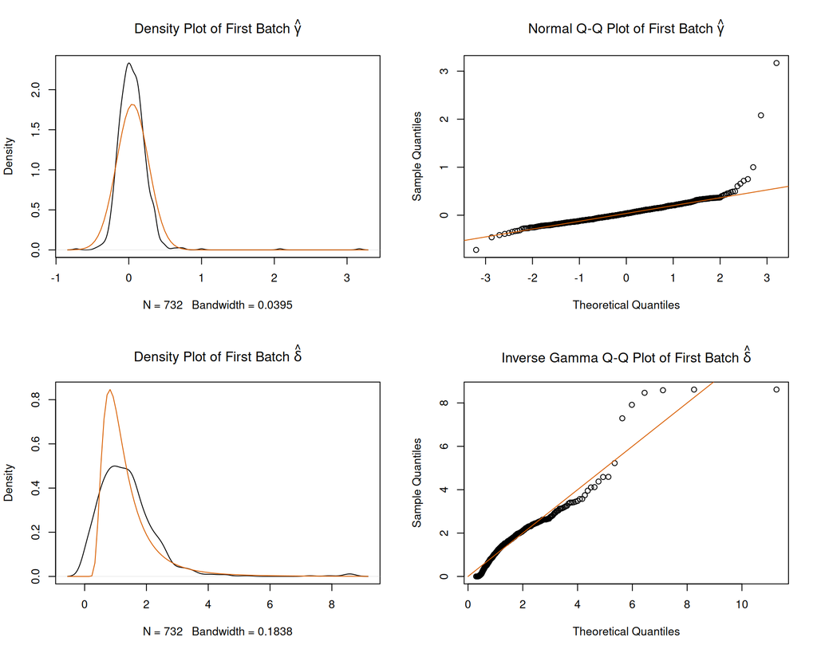

```
## Finding parametric adjustments
```

```
## Adjusting the Data
```

```r
modcombat = model.matrix(~as.factor(as.character(M$Celltype)), data=M)
combat_edata = ComBat(dat=D, batch=M$batch, mod=modcombat, par.prior=TRUE, prior.plots=TRUE)
```

```r
D[1:5,1:5]
```

```
##                 T74_P1_A9_ILC1 T74_P1_B4_NK T74_P1_B7_ILC2 T74_P1_B9_NK
## ENSG00000003056              0            0              0            1
## ENSG00000003402              2           11              2          657
## ENSG00000003756              0            1             48            3
## ENSG00000004534              1            1           4102            2
## ENSG00000004897              0            1              2            2
##                 T74_P1_D10_ILC2
## ENSG00000003056               1
## ENSG00000003402             924
## ENSG00000003756               1
## ENSG00000004534             672
## ENSG00000004897               0
```

```r
combat_edata[1:5,1:5]
```

```
##                 T74_P1_A9_ILC1 T74_P1_B4_NK T74_P1_B7_ILC2 T74_P1_B9_NK
## ENSG00000003056     -13.666835    -8.867236      -11.32170    -7.770285
## ENSG00000003402      36.225949    49.976078       31.28344   653.085592
## ENSG00000003756      16.882753    14.389821       73.11964    16.748636
## ENSG00000004534      -3.000701     9.716396     2301.19951    10.270803
## ENSG00000004897       5.345433     3.075161       12.11363     4.611484
##                 T74_P1_D10_ILC2
## ENSG00000003056      -10.224751
## ENSG00000003402      892.068221
## ENSG00000003756       17.687487
## ENSG00000004534      399.583837
## ENSG00000004897        9.040983
```

Let us now display a tSNE plot for the Combat corrected data set:

```r
library("Rtsne")
set.seed(1)
tsne.out_combat<-Rtsne(t(combat_edata),initial_dims=10,verbose=TRUE,perplexity=30)
```

[output not shown]

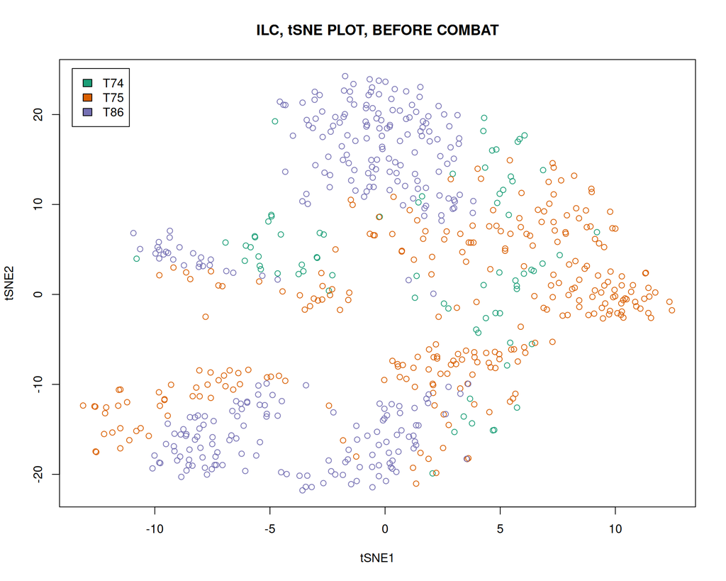

```r
#BEFORE CORRECTION
plot(tsne.out_expr$Y,main="ILC, tSNE PLOT, BEFORE COMBAT",col=factor(M$Donor),xlab="tSNE1",ylab="tSNE2")
legend("topleft",levels(factor(M$Donor)),cex=1,fill=brewer.pal(length(levels(factor(M$Donor))),'Dark2'),inset=0.02)
```

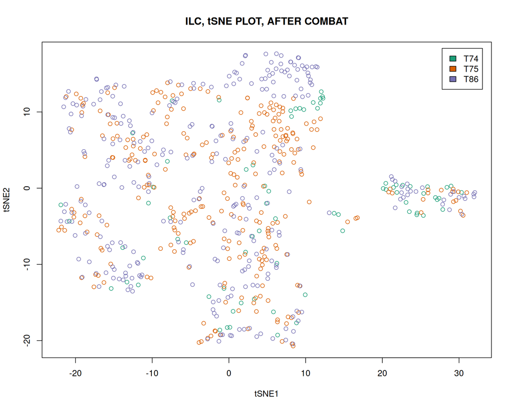

```r
#AFTER COMBAT CORRECTION
plot(tsne.out_combat$Y,main="ILC, tSNE PLOT, AFTER COMBAT",col=as.factor(M$Donor),xlab="tSNE1",ylab="tSNE2")
legend("topright",levels(as.factor(M$Donor)),cex=1,fill=unique(as.factor(M$Donor)),inset=0.02)
```

We see that cells from different Donors seem to be more mixed after Combat correction.

### Correcting for Batch-Effects with MNN

Now we will perform batch-effects correction with Mutial Nearest Neighbours (MNN) algorithm from the “scran” R package developed in the lab of John Marioni, University of Cambridge. The idea of the method is to identify cells between batches having shortest Euclidean distance and hence (presumably!) belonging to the same sub-population (nearest neighbours). Then the difference in expression between the cells is assumed due to technical/batch variation and all other cells are corrected with respect to the identified nearest neighbour cells.

```r
library("scran")
D_T74<-subset(D,select=colnames(D)[grepl("T74",colnames(D))])
D_T75<-subset(D,select=colnames(D)[grepl("T75",colnames(D))])
D_T86<-subset(D,select=colnames(D)[grepl("T86",colnames(D))])

library("batchelor")
#mnn_corrected <- fastMNN(as.matrix(D_T74), as.matrix(D_T75),as.matrix(D_T86))
mnn_corrected <- mnnCorrect(as.matrix(D_T74), as.matrix(D_T75),as.matrix(D_T86))
#mnn_merge<-cbind(mnn_corrected$corrected[[1]],mnn_corrected$corrected[[2]],mnn_corrected$corrected[[3]])
mnn_merge<-assay(mnn_corrected, "corrected")
dim(mnn_merge)
```

```
## [1] 732 648
```

```r
library("Rtsne")
set.seed(1)
tsne.out_mnn<-Rtsne(t(mnn_merge),initial_dims=10,verbose=TRUE,perplexity=30)
```

[output not shown]

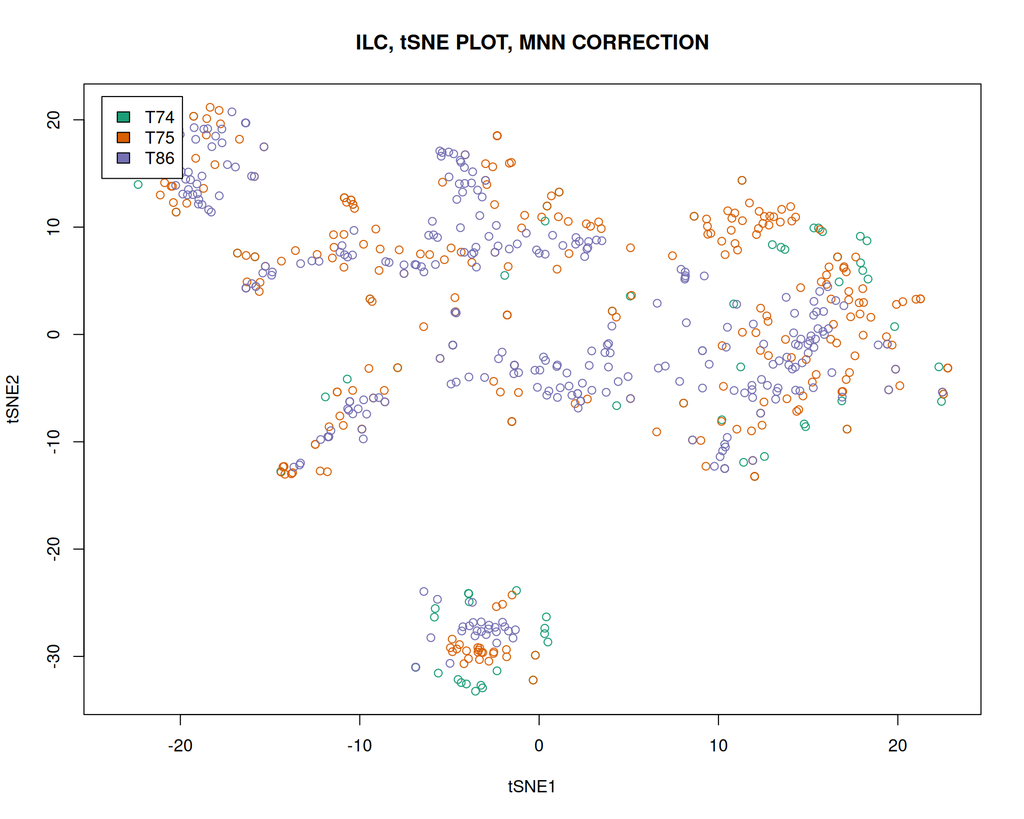

```r
plot(tsne.out_mnn$Y,main="ILC, tSNE PLOT, MNN CORRECTION",col=factor(M$Donor),xlab="tSNE1",ylab="tSNE2")
legend("topleft",levels(factor(M$Donor)),cex=1,fill=brewer.pal(length(levels(factor(M$Donor))),'Dark2'),inset=0.02)
```

### Correcting for Batch-Effects with SCMAP

Now we are going to use a method called SCMAP for integration of two scRNAseq data sets which can be view as a correction for batch-effects. The idea of the method is to use one scRNAseq data set as a reference (e.g. a Human Cell Atlas data can be considered as a reference) and project cells from our particular scRNAseq experiment onto the reference data in order to determine the cell types in our scRNAseq data.

For simplicity we will consider cells from T74 and T75 donors as a reference and project cells from T86 onto the reference. Let us start with creating a SingleCellExperiment object for the reference data set.

```r
library("SingleCellExperiment")
library("scmap")
ref_df<-subset(D,select=colnames(D)[grepl("T74|T75",colnames(D))])
ref_annot<-M[grepl("T74|T75",as.character(M$Donor)),]
ref_annot_scmap<-data.frame(cell_type1=ref_annot$Celltype)
rownames(ref_annot_scmap)<-rownames(ref_annot)
head(ref_annot_scmap)
```

```
##                 cell_type1
## T74_P1_A9_ILC1        ILC1
## T74_P1_B4_NK            NK
## T74_P1_B7_ILC2        ILC2
## T74_P1_B9_NK            NK
## T74_P1_D10_ILC2       ILC2
## T74_P1_E1_ILC3        ILC3
```

```r
sce <- SingleCellExperiment(assays = list(normcounts = as.matrix(ref_df)), colData = ref_annot_scmap)
logcounts(sce) <- log2(normcounts(sce) + 1)
# use gene names as feature symbols
rowData(sce)$feature_symbol <- rownames(sce)
sce <- splitAltExps(sce, ifelse(grepl("^ERCC-", rownames(sce)), "ERCC", "gene"))
# remove features with duplicated names
sce <- sce[!duplicated(rownames(sce)), ]
sce
```

```
## class: SingleCellExperiment
## dim: 732 348
## metadata(0):
## assays(2): normcounts logcounts
## rownames(732): ENSG00000003056 ENSG00000003402 ...
##   ERCC_29.296875:mix1_43.9453125:mix2 ERCC_468.75:mix1_117.1875:mix2
## rowData names(1): feature_symbol
## colnames(348): T74_P1_A9_ILC1 T74_P1_B4_NK ... T75_P3_H9_ILC2
##   T75_P4_H9_ILC1
## colData names(1): cell_type1
## reducedDimNames(0):
## mainExpName: gene
## altExpNames(0):
```

Now we will select most informative genes that provide cell clustering in the reference data set:

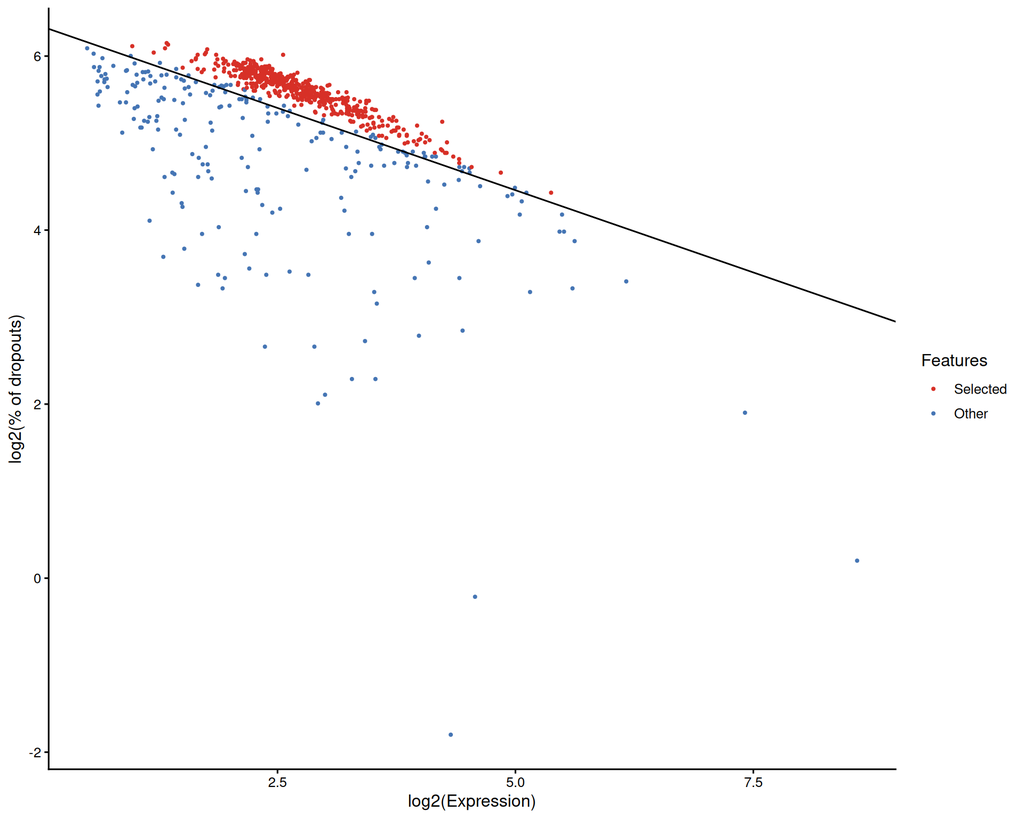

```r
sce <- selectFeatures(sce, suppress_plot = FALSE)
```

```r
table(rowData(sce)$scmap_features)
```

```
##
## FALSE  TRUE
##   232   500
```

Here we index reference data set clustering using medians of genes for each cluster:

```r
sce <- indexCluster(sce)
head(metadata(sce)$scmap_cluster_index)
```

```
##                     ILC1       NK     ILC2 ILC3
## ENSG00000003056 1.000000 0.000000 0.000000    0
## ENSG00000003402 1.584963 6.194009 1.000000    1
## ENSG00000005955 0.000000 0.000000 0.000000    1
## ENSG00000006114 0.000000 1.000000 0.000000    0
## ENSG00000008513 3.700440 1.000000 1.000000    0
## ENSG00000008952 5.832890 1.000000 2.584963    1
```

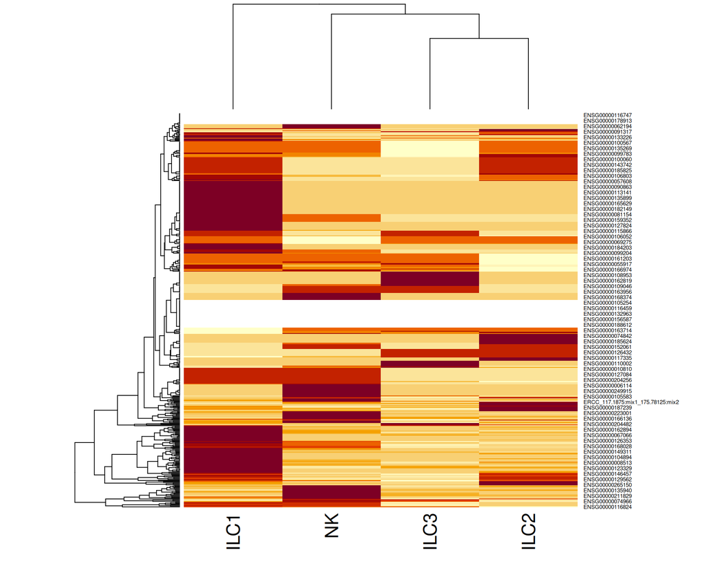

```r
heatmap(as.matrix(metadata(sce)$scmap_cluster_index))
```

Lets us now create a SCE object for the test data set tp be projected onto the reference:

```r
test_df<-subset(D,select=colnames(D)[grepl("T86",colnames(D))])
sce_test <- SingleCellExperiment(assays = list(normcounts = as.matrix(test_df)))
logcounts(sce_test) <- log2(normcounts(sce_test) + 1)
# use gene names as feature symbols
rowData(sce_test)$feature_symbol <- rownames(sce_test)
sce_test <- splitAltExps(sce_test, ifelse(grepl("^ERCC-", rownames(sce_test)), "ERCC", "gene"))
# remove features with duplicated names
sce_test <- sce_test[!duplicated(rownames(sce_test)), ]
sce_test
```

```
## class: SingleCellExperiment
## dim: 732 300
## metadata(0):
## assays(2): normcounts logcounts
## rownames(732): ENSG00000003056 ENSG00000003402 ...
##   ERCC_29.296875:mix1_43.9453125:mix2 ERCC_468.75:mix1_117.1875:mix2
## rowData names(1): feature_symbol
## colnames(300): T86_P1_A1_ILC3 T86_P1_A10_ILC3 ... T86_P4_H5_ILC3
##   T86_P4_H8_ILC3
## colData names(0):
## reducedDimNames(0):
## mainExpName: gene
## altExpNames(0):
```

Now we can project the test data set onto the refernce:

```r
scmapCluster_results <- scmapCluster(
  projection = sce_test, threshold = 0.3,
  index_list = list(
    reference = metadata(sce)$scmap_cluster_index
  )
)
head(scmapCluster_results$scmap_cluster_labs,20)
```

```
##       reference
##  [1,] "unassigned"
##  [2,] "ILC3"
##  [3,] "ILC3"
##  [4,] "unassigned"
##  [5,] "unassigned"
##  [6,] "unassigned"
##  [7,] "ILC3"
##  [8,] "ILC3"
##  [9,] "unassigned"
## [10,] "unassigned"
## [11,] "unassigned"
## [12,] "unassigned"
## [13,] "unassigned"
## [14,] "NK"
## [15,] "unassigned"
## [16,] "unassigned"
## [17,] "unassigned"
## [18,] "ILC3"
## [19,] "unassigned"
## [20,] "unassigned"
```

```r
head(scmapCluster_results$scmap_cluster_siml,20)
```

```
##        reference
##  [1,] 0.17298459
##  [2,] 0.44572133
##  [3,] 0.49633172
##  [4,] 0.09672277
##  [5,]         NA
##  [6,] 0.15442758
##  [7,] 0.49557526
##  [8,] 0.43295443
##  [9,] 0.16884769
## [10,] 0.13381652
## [11,] 0.13938067
## [12,] 0.12702673
## [13,] 0.16973052
## [14,] 0.56767457
## [15,] 0.19470757
## [16,] 0.18266300
## [17,] 0.14917527
## [18,] 0.51367106
## [19,] 0.17732457
## [20,] 0.11778121
```

```r
results<-data.frame(CELS=colnames(test_df),ASSIGNED_LABEL=as.vector(scmapCluster_results$scmap_cluster_labs),TRUE_LABEL=matrix(unlist(strsplit(colnames(test_df),"_")),ncol=4,byrow=TRUE)[,4],SIMILARITY=as.vector(scmapCluster_results$scmap_cluster_siml))
head(results,20)
```

```
##               CELS ASSIGNED_LABEL TRUE_LABEL SIMILARITY
## 1   T86_P1_A1_ILC3     unassigned       ILC3 0.17298459
## 2  T86_P1_A10_ILC3           ILC3       ILC3 0.44572133
## 3  T86_P1_A12_ILC3           ILC3       ILC3 0.49633172
## 4   T86_P1_A3_ILC3     unassigned       ILC3 0.09672277
## 5   T86_P1_A5_ILC3     unassigned       ILC3         NA
## 6   T86_P1_A8_ILC3     unassigned       ILC3 0.15442758
## 7   T86_P1_B1_ILC3           ILC3       ILC3 0.49557526
## 8  T86_P1_B12_ILC3           ILC3       ILC3 0.43295443
## 9   T86_P1_B3_ILC3     unassigned       ILC3 0.16884769
## 10  T86_P1_B5_ILC3     unassigned       ILC3 0.13381652
## 11  T86_P1_B6_ILC3     unassigned       ILC3 0.13938067
## 12  T86_P1_B7_ILC3     unassigned       ILC3 0.12702673
## 13  T86_P1_B8_ILC3     unassigned       ILC3 0.16973052
## 14    T86_P1_B9_NK             NK         NK 0.56767457
## 15  T86_P1_C1_ILC3     unassigned       ILC3 0.19470757
## 16 T86_P1_C10_ILC3     unassigned       ILC3 0.18266300
## 17 T86_P1_C11_ILC3     unassigned       ILC3 0.14917527
## 18 T86_P1_C12_ILC3           ILC3       ILC3 0.51367106
## 19  T86_P1_C2_ILC3     unassigned       ILC3 0.17732457
## 20  T86_P1_C3_ILC3     unassigned       ILC3 0.11778121
```

We can see that there are 127 “unassigned” cells, i.e. where KNN classifier fails to assign their class. Let as calculate the accuracy of assignment for the assigned cells:

```r
results_assigned<-results[as.character(results$ASSIGNED_LABEL)!="unassigned",]
head(results_assigned,20)
```

```
##               CELS ASSIGNED_LABEL TRUE_LABEL SIMILARITY
## 2  T86_P1_A10_ILC3           ILC3       ILC3  0.4457213
## 3  T86_P1_A12_ILC3           ILC3       ILC3  0.4963317
## 7   T86_P1_B1_ILC3           ILC3       ILC3  0.4955753
## 8  T86_P1_B12_ILC3           ILC3       ILC3  0.4329544
## 14    T86_P1_B9_NK             NK         NK  0.5676746
## 18 T86_P1_C12_ILC3           ILC3       ILC3  0.5136711
## 23  T86_P1_C6_ILC3           ILC3       ILC3  0.4655949
## 28 T86_P1_D10_ILC3           ILC2       ILC3  0.3970456
## 29   T86_P1_D11_NK             NK         NK  0.5262334
## 30 T86_P1_D12_ILC3           ILC3       ILC3  0.5097175
## 34  T86_P1_D6_ILC3           ILC3       ILC3  0.4664650
## 38 T86_P1_E10_ILC3           ILC3       ILC3  0.4750463
## 40 T86_P1_E12_ILC3           ILC3       ILC3  0.4968623
## 41  T86_P1_E2_ILC3           ILC3       ILC3  0.4253116
## 42  T86_P1_E3_ILC3           ILC3       ILC3  0.4706919
## 45    T86_P1_E6_NK             NK         NK  0.5219235
## 46    T86_P1_E7_NK             NK         NK  0.5405412
## 48  T86_P1_E9_ILC3           ILC3       ILC3  0.4489822
## 50 T86_P1_F10_ILC3           ILC3       ILC3  0.4821195
## 51 T86_P1_F11_ILC3           ILC3       ILC3  0.4667251
```

```r
table(results_assigned$ASSIGNED_LABEL,results_assigned$TRUE_LABEL)
```

```
##
##        ILC1 ILC2 ILC3 NK
##   ILC1   65   26    0  0
##   ILC2    0    2    2  0
##   ILC3    0    0   60  0
##   NK      0    0    0 18
```

```r
sum(as.character(results_assigned$ASSIGNED_LABEL)==as.character(results_assigned$TRUE_LABEL))/dim(results_assigned)[1]
```

```
## [1] 0.8381503
```

We conclude that the accuracy of assignment is 84% which is not fantastic taking into account that SCMAP failed assignment of almost a half of the cells in the test data set.

### Correcting for Batch Effects with Seurat

```r
library(Seurat)

# --- 1. SETUP AND PREPROCESS (Keep Objects Separate) ---
ref_df <- subset(D, select = colnames(D)[grepl("T74|T75", colnames(D))])
test_df <- subset(D, select = colnames(D)[grepl("T86", colnames(D))])

ref_seurat <- CreateSeuratObject(counts = ref_df, project = "ref", min.cells = 5)
ref_seurat@meta.data$stim <- "ref"
ref_seurat <- subset(ref_seurat, subset = nFeature_RNA > 100)
ref_seurat <- NormalizeData(ref_seurat, verbose = FALSE)

test_seurat <- CreateSeuratObject(counts = test_df, project = "test", min.cells = 5)
test_seurat@meta.data$stim <- "test"
test_seurat <- subset(test_seurat, subset = nFeature_RNA > 100)
test_seurat <- NormalizeData(test_seurat, verbose = FALSE)

# --- 2. FIND VARIABLE FEATURES AND SCALE ---
ref_seurat <- FindVariableFeatures(ref_seurat, nfeatures = 2000, verbose = FALSE)
test_seurat <- FindVariableFeatures(test_seurat, nfeatures = 2000, verbose = FALSE)

features <- SelectIntegrationFeatures(object.list = list(ref_seurat, test_seurat), nfeatures = 2000)

ref_seurat <- ScaleData(ref_seurat, features = features, verbose = FALSE)
test_seurat <- ScaleData(test_seurat, features = features, verbose = FALSE)

# --- 3. RUN PCA ON EACH OBJECT (The missing step for rpca) ---
ref_seurat <- RunPCA(ref_seurat, features = features, verbose = FALSE)
test_seurat <- RunPCA(test_seurat, features = features, verbose = FALSE)

# --- 4. FIND ANCHORS USING RPCA ---
anchors <- FindIntegrationAnchors(
  object.list = list(ref_seurat, test_seurat),
  anchor.features = features,
  reduction = "rpca",
  dims = 1:30,
  scale = FALSE # Since we already scaled, we don't need to scale again
)
```

```
## Computing within dataset neighborhoods
```

```
## Finding all pairwise anchors
```

```
## Projecting new data onto SVD
## Projecting new data onto SVD
```

```
## Finding neighborhoods
```

```
## Finding anchors
```

```
##  Found 159 anchors
```

```r
# --- 5. INTEGRATE ---
seurat_combined <- IntegrateData(anchorset = anchors, dims = 1:30)
```

```
## Merging dataset 2 into 1
```

```
## Extracting anchors for merged samples
```

```
## Finding integration vectors
```

```
## Finding integration vector weights
```

```
## Integrating data
```

```r
# --- 6. DOWNSTREAM ANALYSIS ---
DefaultAssay(seurat_combined) <- "integrated"
seurat_combined <- ScaleData(seurat_combined, verbose = FALSE)
seurat_combined <- RunPCA(seurat_combined, npcs = 30, verbose = FALSE)

seurat_combined <- RunTSNE(seurat_combined, reduction = "pca", dims = 1:20)
seurat_combined <- FindNeighbors(seurat_combined, reduction = "pca", dims = 1:20)
seurat_combined <- FindClusters(seurat_combined, resolution = 0.6)
```

```
## Modularity Optimizer version 1.3.0 by Ludo Waltman and Nees Jan van Eck
##
## Number of nodes: 648
## Number of edges: 29728
##
## Running Louvain algorithm...
## Maximum modularity in 10 random starts: 0.7811
## Number of communities: 5
## Elapsed time: 0 seconds
```

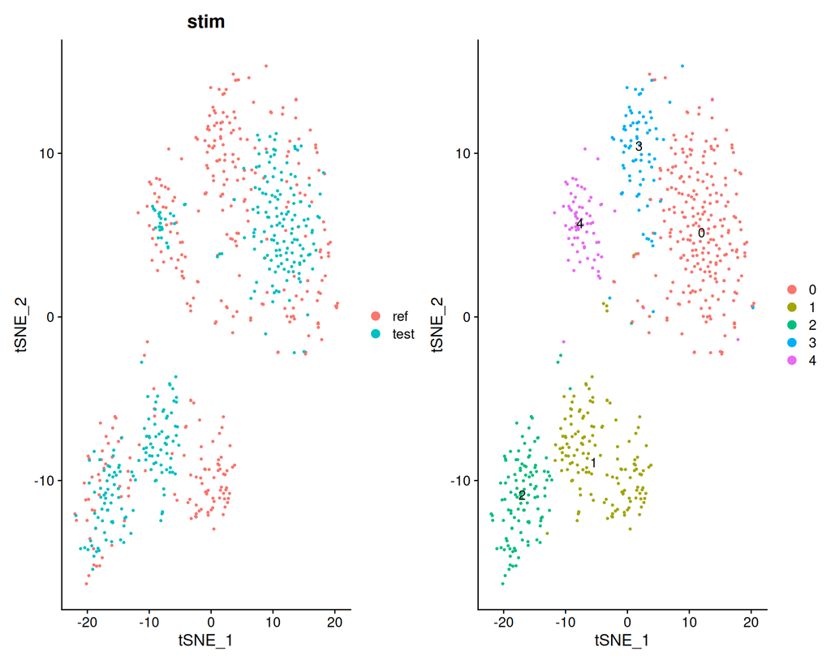

```r
# --- 7. VISUALIZATION ---
p1 <- DimPlot(seurat_combined, reduction = "tsne", group.by = "stim", pt.size = 0.5)
p2 <- DimPlot(seurat_combined, reduction = "tsne", label = TRUE, pt.size = 0.5)
p1 + p2
```